# R Notebook: r-intro

Peyton Urquhart [peyton.urquhart]

```
## i SHA-1 hash of file is 77cdf61374e960979950504ea4e1c0dbbf40b7f3
```

```
## [1] "Retreived Declaration of Independence at:"
```

```
## [1] "D:/_git_/peyton.urquhart/r-intro/draft.txt"
```

```
## [1] "D:/_git_/peyton.urquhart/r-intro/final.txt"
```

# Handshake

handShake(n, plotMe) calculates the total number of handshakes that must occur between n people such that each individual shakes everybody’s hand exactly one time. Handshakes may be visualized using plotMe=TRUE.

Handshake plot for n = 4 people:

```
## [1] 6
```

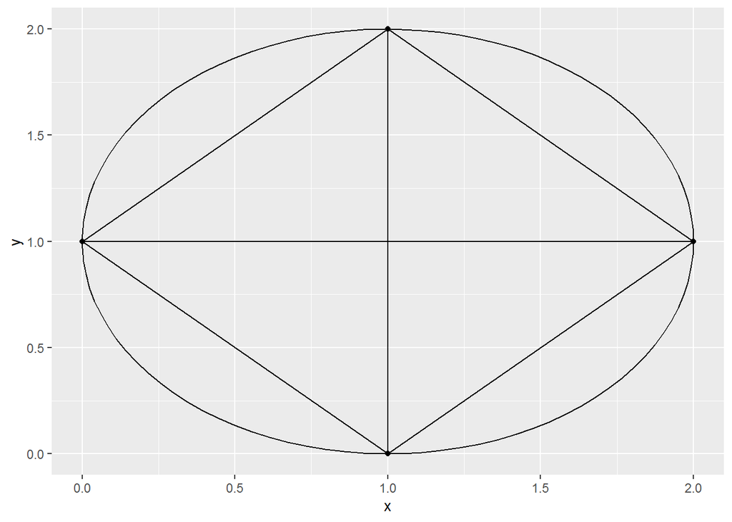

Handshake plot for n = 8 people:

```
## [1] 28
```

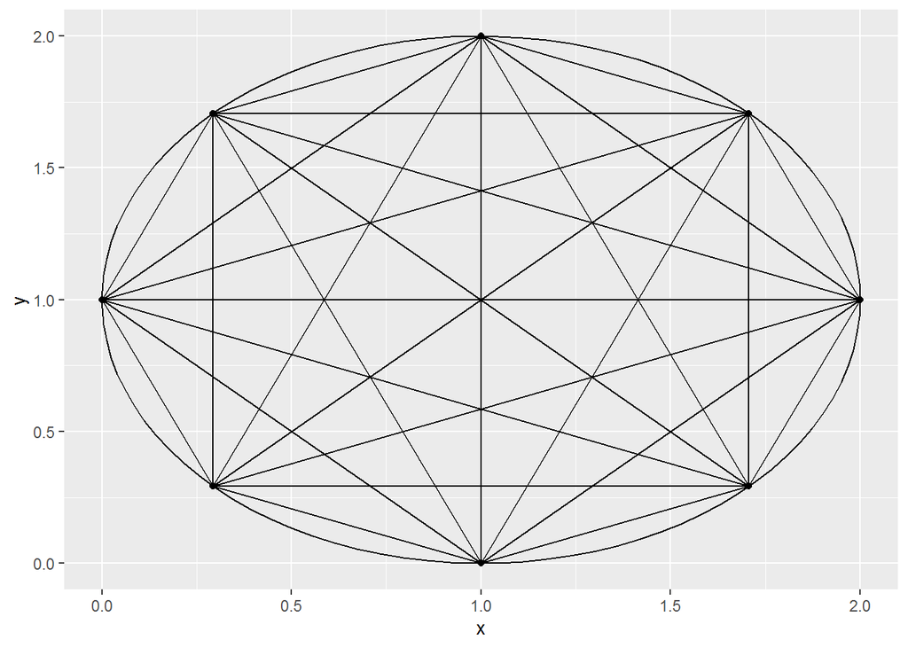

Handshake plot for n = 24 people:

```
## [1] 276
```

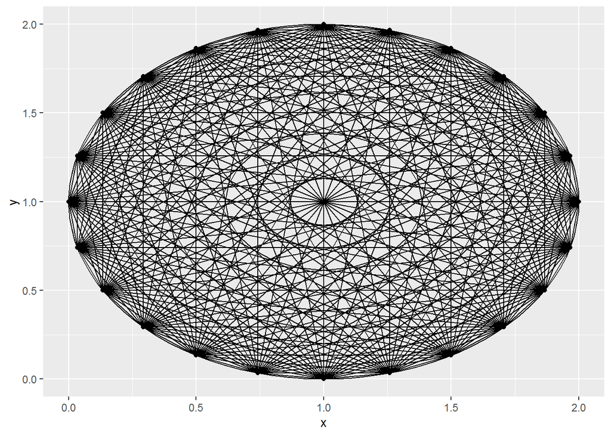

## Function Parameters

- n : Total number of people that must shake everybody’s hand exactly once
- plotMe : Print a plot of the handshake simulation?

## Calculation of plotMe

circleData (c(x,y), r, npoints): Generates data consisting of n points, each at equal and increasing angles from c (the center) which (when connected) form a circle. This is achieved by generating a sequence s of radians (0, … ,2*PI) in equal intervals, followed by two more sequences x,y where x[i] = (c.x + r cos(s[i])) and y[i] = (c.y + r sin(s[i])).

circleData() is called once to plot an initial circle drawn with lines, and once again with npoints = n to plot individual points corresponding to each person in the handshake simulation.

Finally, for each individual point on the circle, n - 1 lines are drawn connecting the given point with all other points on the circle.

# Alphabet Declaration of Independence

countLowerCaseChars_f(filepath): Counts lower case alphabetical characters in a .txt file and returns a data frame. Here it is used to count chars in the Declaration of Independence draft and final copies.

Declaration of independence draft table:

| a | b | c | d | e | f | g | h | i | j | k | l | m | n | o | p | q | r | s | t | u | v | w | x | y | z | OTHER |
| --- | --- | --- | --- | --- | --- | --- | --- | --- | --- | --- | --- | --- | --- | --- | --- | --- | --- | --- | --- | --- | --- | --- | --- | --- | --- | --- |
| 555 | 117 | 225 | 260 | 1090 | 246 | 164 | 441 | 575 | 19 | 20 | 264 | 196 | 546 | 658 | 180 | 7 | 556 | 572 | 791 | 244 | 97 | 130 | 12 | 108 | 3 | 354 |

Declaration of independence final table:

| a | b | c | d | e | f | g | h | i | j | k | l | m | n | o | p | q | r | s | t | u | v | w | x | y | z | OTHER |
| --- | --- | --- | --- | --- | --- | --- | --- | --- | --- | --- | --- | --- | --- | --- | --- | --- | --- | --- | --- | --- | --- | --- | --- | --- | --- | --- |
| 483 | 95 | 186 | 254 | 867 | 182 | 130 | 352 | 454 | 16 | 14 | 229 | 146 | 488 | 517 | 138 | 6 | 428 | 481 | 648 | 212 | 74 | 97 | 9 | 81 | 4 | 293 |

## Visualization of Differences Between Drafts

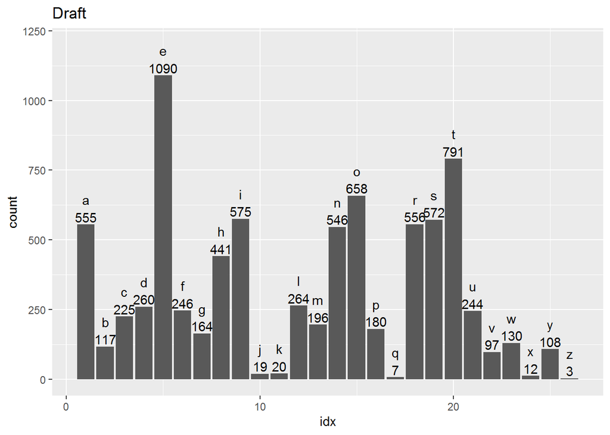

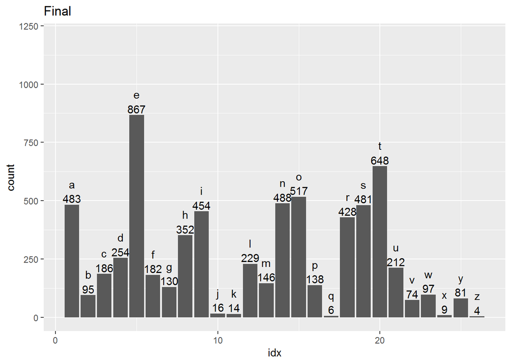

# Determinant of 3 x 3 Matrix

det_3x3(mat, print): mat {<a, b, c> <d, e, f> <g, h, i>} Computes the determinant of a 3x3 matrix: mat using 3 sub-matrices {<e, f> <h, i>}, {<d, f> <g, i>}, {<d, e> <g, h>}. a|efhi| - b|dfgi| + c|degh|. Use print=TRUE to print the origional and sub-matrices.

```
##      [,1] [,2] [,3]
## [1,]    6    1    1
## [2,]    4   -2    5
## [3,]    2    8    7
##      [,1] [,2]
## [1,]   -2    5
## [2,]    8    7
##      [,1] [,2]
## [1,]    4    5
## [2,]    2    7
##      [,1] [,2]
## [1,]    4   -2
## [2,]    2    8
```

```
## [1] -306
```